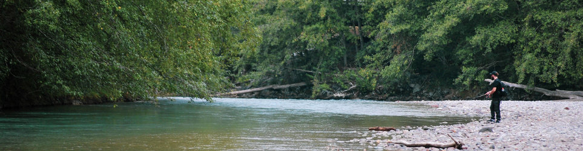

# STAT545A - Homework 1

Welcome, this is my personal repository for the first assignment in **STAT545**.

## About me

My name is *Carl-Adam Mattsson* and two years ago I decided to leave my home in Sweden and move to Vancouver. The reason for moving originated from a dream I had: living abroad in a foreign country. Canada, and more specifically Vancouver, were at the top of my list, because I have always wanted to continue my graduate studies at the University of British Columbia and of course, the stunning scenery in British Columbia that never ceases to astonish me.

I enrolled in the **Bioinformatics Master’s program** in September 2017 and I am currently working with Dr. Peter Lansdorp and Dr. Intan Schrader at the Terry Fox Laboratory, British Columbia Cancer Agency in a medical genetics project, looking at structural genomic rearrangements related to cancer and cancer predisposition. In particular, we are developing and refining a new sequencing method called Single-cell DNA template strand sequencing, which has the potential to revolutionize the way we look at genetic diversity in cancer. Single-cell DNA template strand sequencing, or strand-seq, is a technique for the selective sequencing of a daughter cell’s parental template strands. This technique has many applications, including the identification of sister chromatid exchanges in the parental cell prior to segregation, the identification of misoriented contigs during alignment of reads to the reference genome, and the assessment of non-random segregation of sister chromatids.

Besides continuing my research and expanding my knowlede in **R**, I have a huge pasion for everything out-dorsy. Especially fishing and hiking. [Here](https://ibb.co/eVc5N9) is a picture of me showcasing one of the biggest Northern Pike I’ve ever caught. This beast weight in at 11kg and landing this fish is truely a fishermans dream come true. Also, I love listening and creating music. I started to play the guitar when I was 10 years old and since, not a single day goes bye without me gripping that fretboard. [Here](https://ibb.co/nM48aU) is a photo of me playing a live show in Sweden a few years back.

Feel free to visit my [UBC blog](https://blogs.ubc.ca/mattsada/) or connect with me on [Linkedin](https://www.linkedin.com/in/carl-adam-mattsson-48305aa7/). Assignment summaries with appropriate links for STAT545 are provided in the table below.

| **Assignment** | **Due date** | **Peer Review Due Date** | **Peer Review Link** |
| --- | --- | --- | --- |
| [Homework 1](https://github.com/STAT545-UBC-students/hw01-mattsada/blob/master/hw01_gapminder.md) | September 18, 2018 | September 24, 2018 | Review 1, Review 2 |
| Homework 2 | September 25, 2018 | October 01, 2018 | Review 1, Review 2 |
| Homework 3 | October 02, 2018 | October 08, 2018 | Review 1, Review 2 |
| Homework 4 | October 09, 2018 | October 15, 2018 | Review 1, Review 2 |
| Homework 5 | October 19, 2018 | October 24, 2018 | Review 1, Review 2 |

## Useful resources

- The main website for STAT545 created by that repository is found [here.](http://stat545.com/Classroom/)
- R markdown cheat-sheets can be found [here](https://www.rstudio.com/wp-content/uploads/2015/02/rmarkdown-cheatsheet.pdf) and [here.](https://www.rstudio.com/wp-content/uploads/2016/03/rmarkdown-cheatsheet-2.0.pdf)
- Markdown cheat-sheet can be found [here.](https://github.com/adam-p/markdown-here/wiki/Markdown-Cheatsheet)
- The `ggplot2` cheat-sheet can be found [here.](https://www.rstudio.com/wp-content/uploads/2015/03/ggplot2-cheatsheet.pdf)

## R markdown for Gapminder exploration

The `gapminder` dataset is a massive UN database that compares the populations, gdp per capita, and life expectancy for most countries in 5 year incriments between 1952 and 2007. For initial exploratory analysis on this dataset and R markdown source code follow links in table bellow.

| **Title** | **Format** | **Link** |
| --- | --- | --- |
| Gapminder dataset exploration | Markdown (.md) | [link](https://github.com/STAT545-UBC-students/hw01-mattsada/blob/master/hw01_gapminder.md) |
| R markdown source code | R markdown (.Rmd) | [link](https://github.com/STAT545-UBC-students/hw01-mattsada/blob/master/hw01_gapminder.Rmd) |

## Reflections and thoughts

All changes was made in Rstudio (Version 1.1.453) and then pushed to Github.

Thanks for visiting my repository! I’ll leave you with one of my favorite quotes by Theodosius Dobzhansky:

> Nothing in Biology Makes Sense Except in the Light of Evolution